# Class 2: Causes, Radicalisation, Mobilisation

Causes: Setting the stage for political violence

[Dr. Michael C. Zeller](https://michaelzeller.de)

# Opening notes

[Open Sticker](https://tenor.com/view/open-gif-14209777)from [Open Stickers](https://tenor.com/search/open-stickers)

## Syllabus reading check

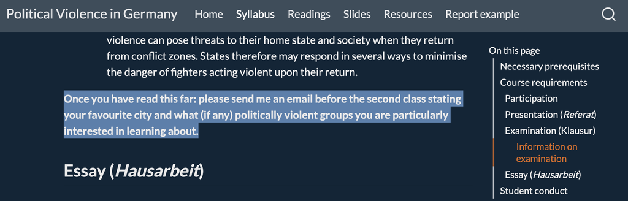

## Students’ favourite cities

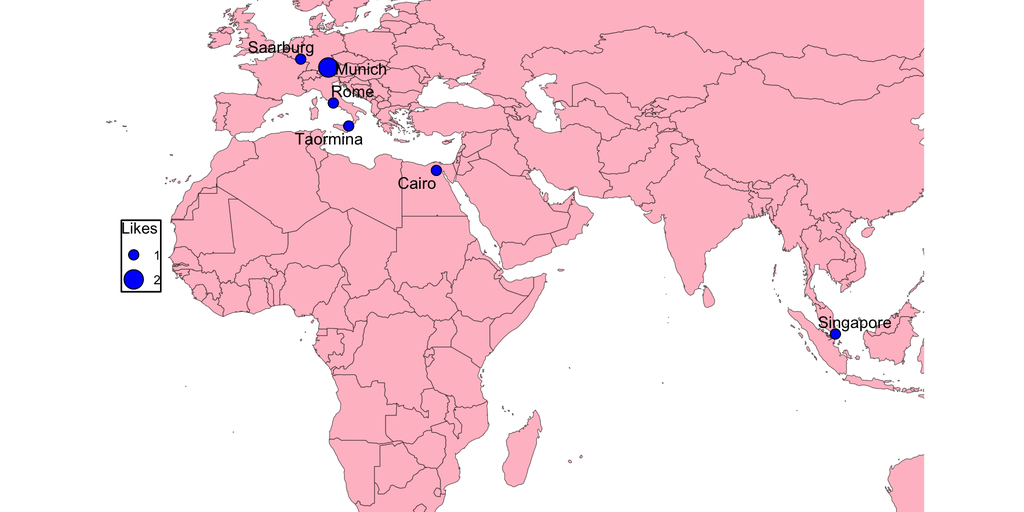

## Presentation groups

Remember: topic to me at least by Week 4

- December
- January

Presentations line-up

| Date | Presenters | Method |
| --- | --- | --- |
| 7 Dec: |  | TBD |
| 14 Dec: |  | TBD |
| 21 Dec: |  | TBD |

Presentations line-up

| Date | Presenters | Method |
| --- | --- | --- |
| 11 Jan: |  | TBD |
| 18 Jan: |  | TBD |
| 25 Jan: |  | TBD |

# A causal framework of political violence

- three organising questions
- common problems
- levels of causation
  - macro-level
  - meso-level
  - micro-level

[Thats Another Reason Why Gill GIF](https://tenor.com/view/thats-another-reason-why-gill-engvid-more-reasons-why-all-the-more-reason-to-gif-23032625)from [Thats Another Reason Why GIFs](https://tenor.com/search/thats+another+reason+why-gifs)

## Three organising questions (Crenshaw 1981)

- Terrorist violence communicates a political message; its ends go beyond damaging an enemy’s material resources
1. why does terrorism occur?
   - *predictive*/*causal* questions
2. how do the processes of terrorism work?
   - *processual*/*mechanistic* questions
3. what are its social and political effects?
   - *descriptive* and *causal* questions

## Common problems (Crenshaw 1981)

(still applicable to significant portions of political violence and research several decades on…)

- logical comparability
- specification of the relationship of variables to each other
- rank-ordering of variables in terms of explanatory power

## 3 levels of causation (Crenshaw 1981)

1. broad environment/contextual factors (macro-level)
2. circumstances and actors (meso-level)
3. psychological variables that encourage or inhibit (micro-level)
- these *levels* are a useful and widely applicable analytical framework

## Context (macro-level): preconditions

**Any ideas what is depicted here?**

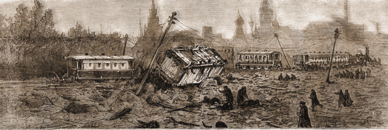

## Context (macro-level): preconditions

- preconditions, factors setting stage for terrorism over the long run
  - enabling or permissive factors provide opportunities
    - e.g., modernisation - Narodnaya Volya: operating in imperial Russia made possible by rail infrastructure
    - e.g., urbanisation - 19th century urban development of Paris by Haussman: riots and barricades less feasible, terrorism provides an alternative
    - e.g., absence of effective security measures - “necessary”
  - situations that directly inspire and motivate terrorist campaigns
    - grievances: e.g., group-based discrimination, relative deprivation (*Revisionist History* podcast: ‘[Saigon, 1965](https://www.pushkin.fm/podcasts/revisionist-history/saigon-1965)’)
    - *lack of opportunity for political participation*

## Context (macro-level): precipitants

- precipitants, specific events that immediately precede the occurrence of terrorism

> a common pattern of government actions that act as catalysts for terrorism. Government use of unexpected and unusual force in response to protestor reform attempts often compels terrorist retaliation. (p384)

Examples?

## Context (macro-level): precipitants

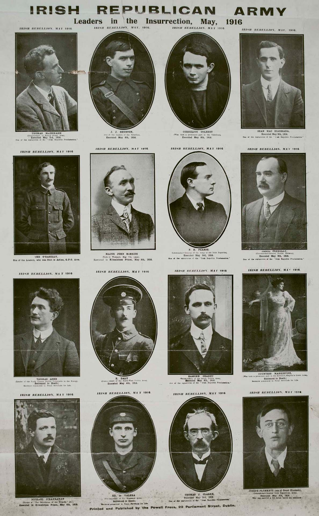

→

→

→

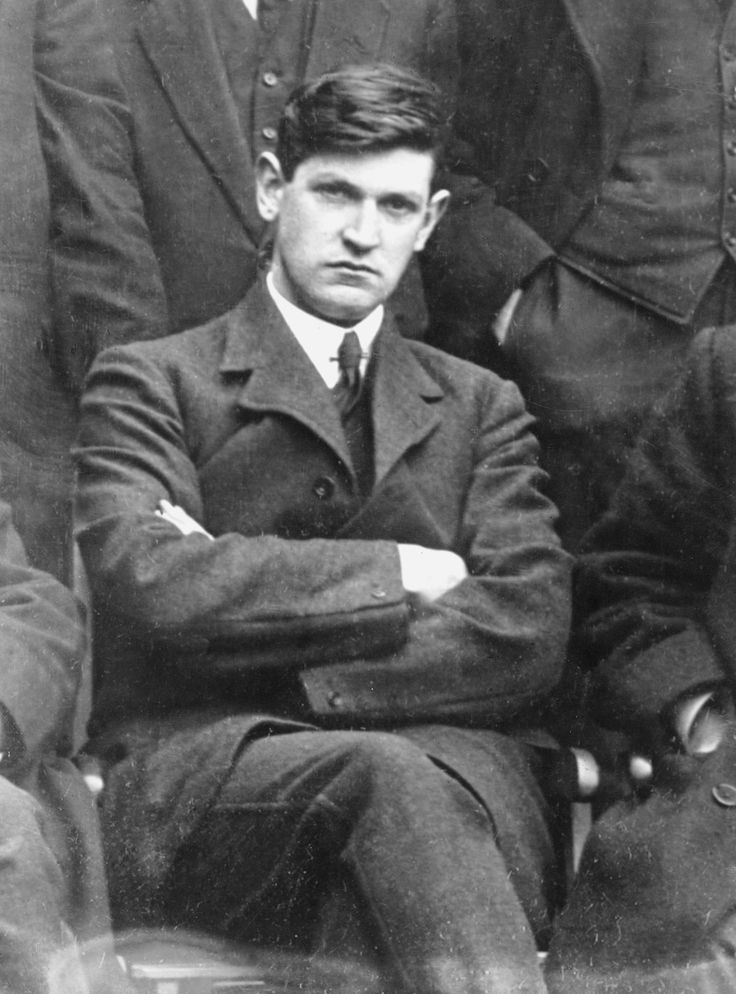

## Context (macro-level): precipitants

- precipitants, specific events that immediately precede the occurrence of terrorism

> a common pattern of government actions that act as catalysts for terrorism. Government use of unexpected and unusual force in response to protestor reform attempts often compels terrorist retaliation. (p384)

Examples?

- execution of 1916 Easter Rising heroes in Ireland
- Protestant violence in response to Catholic civil rights movement in northern Ireland
- RAF emerges after 1968 Beno Ohnesorg death by police violence

## Circumstances (meso-level) (Crenshaw 1981)

- terrorist behaviour as “rational”
  - based on assumption that terrorist organisations have consistent sets of values, beliefs, and images of the environment. Hence, terrorism is seen collectively as a logical means
- variety of goals
  - from revolutionary - e.g., new state, new system
  - to (essentially) conservative - e.g., preserve social group relations, power arrangements

## Circumstances (meso-level): variety of goals (1981)

- can serve long-term strategy and/or proximate objectives
- gain attention, win support
- disrupt/discredit government/state
- provoke reactions:
  - affects public attitudes positively and negatively, creating either sympathy in a potential constituency or fear and hostility in an audience identified as the “enemy.”
  - government counteraction
- internal organisation functions: control, discipline, morale-building
- actors’ impatience

## Circumstances (meso-level) (Crenshaw 1981)

> The observation that terrorism is a weapon of the weak is hackneyed but apt. (p387)

**What does this mean? Do you agree?**

- inexpensive, simple
- contrast: James C. Scott’s book (1985), *Weapons of the Weak: Everyday Forms of Peasant Resistance*

## Psychological (micro-level): common traits (Crenshaw 1981)

two fundamental questions about the psychological basis of terrorism:

1. why the individual takes the first step and chooses to engage in terrorism: why join? Does the terrorist possess specific psychological predispositions, identifiable in advance, that suit them for terrorism?
   - radicalisation and engagement
2. Why does involvement continue? What are the psychological mechanisms of group interaction?
   - persistence or endurance

## Psychological (micro-level): common traits (Crenshaw 1981)

- ego-defensive needs
- cognitive processes
- socialisation
- in interaction with a specific situation
- different acts of terror can carry differences in psychological demands
  - extremely discriminate (e.g., assassination) to broadly indiscriminate (recall patterns of violence conceptual framework)

BUT: avoid stereotyping the terrorist or oversimplifying: No single motivation or personality can be valid for all circumstances

## Psychological (micro-level): normality (Crenshaw 1981)

> “the outstanding common characteristic of terrorists is their normality”

> The West German psychiatrist who conducted a pretrial examination of four members of the RAF concluded that they were “intelligent,” even “humorous,” and showed no symptoms of psychosis or neurosis and “no particular personality type.” (p390)

## Psychological (micro-level): difficulties (Crenshaw 1981)

studying individuals engaged in terrorism presents problems:

- preconditions change over time and precipitants are unpredictable
- interviewing terrorists: may discover subsequent rationalisations instead of prior attitudes/motivations

## Psychological (micro-level): endurance (Crenshaw 1981)

Within terrorist groups, individual/group dynamics of …

- commitment,
- risk,
- solidarity,
- loyalty,
- guilt,
- revenge,
- isolation

discourage a change in behaviour (and at the organisational level, strategy)—even when contextual conditions change.

# Politically violent groups connected to Germany

- open to discussion on all sorts of non-state (potentially) politically violent groups
- highlighting roster of PV organisations to be assigned
- introduction of those (and other) cases

[Germany History GIF](https://tenor.com/view/germany-history-funny-what-whats-happening-gif-17835309)from [Germany GIFs](https://tenor.com/search/germany-gifs)

## (In)famous PV groups in or connected to Germany

> “Those who only know one country, know no country” - Seymour Martin Lipset (inspired by Alexis de Tocqueville)
- well-known and covered in research literature
- diverse strategies, objectives, and ideological characteristics
- active in Germany and/or banned by Germany (or EU)
- we will also discuss other cases (e.g., IRA), including ones you know of, just remember:
  - aim is to *analyse* and *understand*
  - most PV groups involve charged political issues, so remember:
    - treat each other with mutual respect
    - most are working in 2nd/3rd/4th language, so do not assume provocation if you disagree with an expression

## (In)famous PV groups in or connected to Germany

*al-Qaeda* (alQaeda, transnational),  
*Antifaschistische Aktion* (Antifa, Germany and elsewhere),  
*Islamic State* (IS, transnational),  
*Nationaldemokratische Partei Deutschlands* (‘National Democratic Party of Germany,’ NPD, Germany),  
*National Socialist Underground* (NSU, Germany),  
*Partiya Karkerên Kurdistanê* (‘Kurdistan Workers’ Party,’ PKK, Turkey, Syria and several other countries including Germany),  
*Rote Armee Fraktion* (‘Red Army Fraction,’ RAF, Germany),

## al-Qaeda

- Territory of action: international
- Organisational structure: (hierarchical) network
- Membership: large
- (main) Objective: global Islamic caliphate
- (common) Targets: U.S. and Western institutions and societies
- Repertoire of actions: terrorism

[figure not shown]

## Antifa

- Territory of action: international
- Organisational structure: network
- Membership: large
- (main) Objective: oppose fascist forces
- (common) Targets: political opponents
- Repertoire of actions: low-level violence, property damage, doxxing

[figure not shown]

## Islamic State

- Territory of action: international
- Organisational structure: network
- Membership: large
- (main) Objective: Islamic caliphate
- (common) Targets: political, ethnic, religious opponents
- Repertoire of actions: terrorism, militarised combat

[figure not shown]

## National Socialist Underground

- Territory of action: Germany
- Organisational structure: network
- Membership: small
- (main) Objective: terrorise non-ethnic Germans
- (common) Targets: non-ethnic Germans
- Repertoire of actions: murder, robbery

[figure not shown]

## Nationaldemokratische Partei Deutschlands (NPD)

- Territory of action: Germany
- Organisational structure: hierarchical
- Membership: large
- (main) Objective: German ethno-state
- (common) Targets: political and ethnic opponents
- Repertoire of actions: low-level violence, support for terrorism

[figure not shown]

## Partiya Karkeren Kurdistane

- Territory of action: prominently Turkey, but international advocates
- Organisational structure:
- Membership: large
- (main) Objective: Kurdish statehood
- (common) Targets: Turkish military and state
- Repertoire of actions: guerrilla activity

[figure not shown]

## Rote Armee Fraktion

- Territory of action: Germany
- Organisational structure: network
- Membership: small
- (main) Objective: revolutionary state
- (common) Targets: German state, right-wing figures
- Repertoire of actions: kidnapping, robbery, bombing, assassination

[figure not shown]

# Open data - Global Terrorism Database

- Visualisation
- Explanatory note
- Data table

[interactive chart not shown]

The visualisation is of a small subset of the [Global Terrorism Database](https://www.start.umd.edu/data-tools/GTD) (GTD) and illustrates the temporal development of different actors behind political violence in Germany. The incidents include ideologically distinct actors and movements, such as neo-Nazi extremism, PKK-related violence, jihadi-inspired attacks, and National Socialist Underground (NSU) activity. The data shows the frequency of these actors’ political violence over time.

| Year | Group | Attacks |
| --- | --- | --- |
| 1991 | Kurdish Militants | 5 |
| 1991 | Neo-Nazi extremists | 17 |
| 1992 | Kurdish Militants | 1 |
| 1992 | Kurdistan Workers' Party (PKK) | 22 |
| 1992 | Neo-Nazi extremists | 104 |
| 1994 | Kurdistan Workers' Party (PKK) | 14 |
| 1994 | Neo-Nazi extremists | 37 |
| 1995 | Kurdistan Workers' Party (PKK) | 91 |
| 1995 | Right-wing extremists | 5 |
| 1996 | Kurdish Militants | 2 |

[output cut: 24 more lines]

**Data download**

# Other PV groups that will crop up in readings

## Brigate Rosse

- Territory of action: Italy
- Organisational structure:
- Membership: small
- (main) Objective: revolutionary state
- (common) Targets: Italian state institutions and NATO
- Repertoire of actions: robberies, kidnapping, low-level violence

[figure not shown]

## Blood & Honour

- Territory of action: international (originally U.K.)
- Organisational structure: network
- Membership: large
- (main) Objective: white ethnostate
- (common) Targets: political and ethnic opponents
- Repertoire of actions: low-level violence, terrorism

[figure not shown]

## Euskadi Ta Askatasuna (ETA, ‘Basque Homeland and Liberty’)

- Territory of action: Basque country
- Organisational structure: hierarchical
- Membership: large
- (main) Objective: leftist revolution, independent state
- (common) Targets: state institutions
- Repertoire of actions: kidnapping, terrorism

[figure not shown]

## Fuerzas Armadas Revolucionarias de Colombia

- Territory of action: Colombia
- Organisational structure: hierarchical
- Membership: large
- (main) Objective: leftist revolution
- (common) Targets: state institutions, other paramilitaries
- Repertoire of actions: kidnapping, terrorism, drug trade

[figure not shown]

## Grey Wolves

- Territory of action: international (originally Turkish)
- Organisational structure: hierarchical
- Membership: large
- (main) Objective: promote Turkish nationalism
- (common) Targets: political opponents
- Repertoire of actions: low-level violence

[figure not shown]

## Hammerskins

- Territory of action: international (originally U.S.)
- Organisational structure: network
- Membership: large
- (main) Objective: white ethnostate
- (common) Targets: political and ethnic opponents
- Repertoire of actions: low-level violence, terrorism

[figure not shown]

## Hezbollah

- Territory of action: Lebanon, but also transnational
- Organisational structure: hierarchical
- Membership: large
- (main) Objective: Islamic state in Lebanon
- (common) Targets: Western forces, the power-sharing in Lebanon
- Repertoire of actions: terrorism

[figure not shown]

## Hizb ut-Tahrir

- Territory of action: international
- Organisational structure: network
- Membership: large
- (main) Objective: united Islamic caliphate
- (common) Targets: political and ethnic opponents
- Repertoire of actions: low-level violence, incitement to violence, terrorism

[figure not shown]

## Irish Republican Army

- Territory of action: British Isles
- Organisational structure: hierarchical
- Membership: large
- (main) Objective: united, independent Ireland
- (common) Targets: British military and institutions
- Repertoire of actions: terrorism

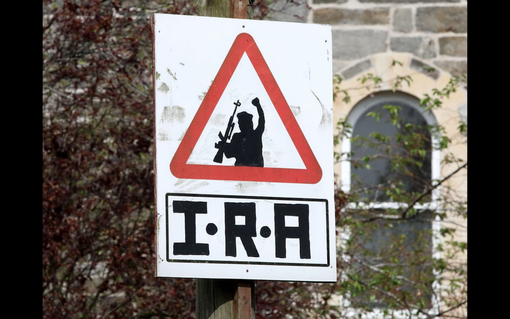

## Kommunistische Partei Deutschlands (KPD)

- Territory of action: Germany, but with important international links
- Organisational structure: hierarchical
- Membership: large
- (main) Objective: communist/socialist revolution
- (common) Targets: political opponents
- Repertoire of actions: low-level violence and agitation for revolution

[figure not shown]

## Liberation Tigers of Tamil Eelam

- Territory of action: Sri Lanka, but also transnational
- Organisational structure: hierarchical
- Membership: large
- (main) Objective: independent Tamil state
- (common) Targets: Sinhalese dominated Sri Lankan state
- Repertoire of actions: assassination, guerrilla activity

[figure not shown]

## Sozialistische Reichspartei (SRP)

- Territory of action: Germany
- Organisational structure: hierarchical
- Membership: large
- (main) Objective: revive national socialist movement
- (common) Targets: political opponents
- Repertoire of actions: low-level violence, support for state violence

[figure not shown]

# Assigning groups for in-depth study

[figure not shown]

To get assigned a group to study in depth, scan the QR code or click this **[LINK](https://script.google.com/macros/s/AKfycbwZ8ht1c8OKYI5vLXMe1iHc3lmBazgij-lBj3Reeut6LryLNZqTjtOqU2k22NcXqoJF/exec)**

You will be randomly assigned one of these groups:

- Antifa
- RAF - Rote Armee Fraktion
- IS - Islamic State
- alQaeda
- NPD/Heimat
- NSU - Nationalsozialistischer Untergrund
- PKK - Partiya Karkerên Kurdistanê

# Testing: determinants of right-wing terrorism in the U.S.

- Piazza (2017)
  - theorising and testing causes

[Orange Terror GIF](https://tenor.com/view/orange-terror-alert-american-dad-gif-20396506)from [Orange GIFs](https://tenor.com/search/orange-gifs)

## Piazza (2017) - testing causes

- Three groups of motivations (p. 54)
  - economic hardships and grievances (mechanism: drive resentment and support for terrorism)
  - greater inclusion and empowerment of women and racial minorities (mechanism: perceived threat to privilege)
  - resentment toward the U.S. political system and government (mechanism: necessitates ‘resistance against tyranny’)

Lays out differing theoretical/empirical contentions/findings about these motivations—and sets out to resolve them (theory-based and empirics-based puzzles) (Day and Koivu 2019)

## Piazza (2017) - research design

> the study uses a cross-sectional panel time series design to examine the predictive quality of a series of state and national-level economic, social and political indicators on counts of domestic terrorist attacks launched by right-wing terrorist movements and individuals in the 50 US states for the period 1970–2011.

Let’s break this down:

## Piazza (2017) - research design

**the study uses a cross-sectional panel time series design to examine the predictive quality of a series of state and national-level economic, social and political indicators on counts of domestic terrorist attacks launched by right-wing terrorist movements and individuals in the 50 US states for the period 1970–2011**

- ‘cross-sectional panel time series’ = different clusters of units of analysis over time
  - ‘in the 50 US states for the period 1970–2011’ = state-year is the unit of analysis (see Note 14)
- ‘predictive quality’ = research objective, *predict* (rather than ‘describe’ or ‘explain’), here meaning *inferential statistics*
- ‘series of state and national-level economic, social and political indicators’ = the (groups of) *independent variables* (IVs), corresponding to the 3 groups of motivations
- ‘counts of domestic terrorist attacks launched by right-wing terrorist movements and individuals’ = *dependent variable* (DV)

## Piazza (2017) - research design

| Variable group | Indicators |
| --- | --- |
| Economic grievance | Per cent in poverty |
|  | Per cent employed in manufacturing |
|  | Number of individual farms in state |
| Societal changes | Rate of abortion |
|  | Per cent of labour force that is female |
|  | Change in non-white state population |
| ‘Big government’ | measure of Democrat party dominance |
|  | U.S. President a Democrat in given year |
|  | Average income tax rate |

## Reading a regression table

Remember: regression is a tool for understanding a phenomenon as a linear function (generally) → (y = mx + b)

1. Numbers not in parentheses next to a variable: regression coefficient: expected change in DV for a one-unit increase in IV. NB: ositive or negative relationship?
2. Numbers inside parentheses next to a variable: standard error: estimate of the standard deviation of the coefficient
3. Asterisks/‘stars’: statistical significance: probability of results as extreme as observed result, under the assumption that the null hypothesis is correct. Smaller p-value means such an observation would be less likely under null hypothesis; hence, significance. Statistical significance suggests more precise estimates—NOT necessarily that one IV is more important than another.

## Piazza (2017) - abridged regression table

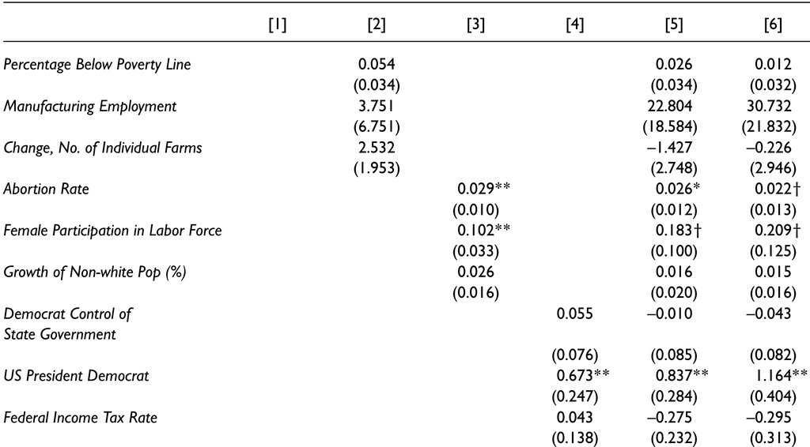

## Piazza (2017) - conclusions

1. economic factors are not reliable predictors of terrorist activity
2. social factors help drive right-wing terrorism. (‘ills afflicting “traditional” American society’)
3. partisan control over government matters at the national level, but not the state level, in determining right-wing terrorism

# Any feedback for this class?

Anonymous feedback here: https://forms.gle/NfF1pCfYMbkAT3WP6

Alternatively, please send me an email: m.zeller@lmu.de

Questions about groups next meeting: (1) Was radicalisation of members motivated more by identity than by ideology? (2) Could individuals realistically have become radicalised without joining a social group connected to the organisation? (3) Was radicalisation into the group mostly *sudden* or *gradual*? (4) How did the group’s narratives portray its members/community: victims, defenders, revolutionaries, religious warriors, other? (5) Did major political events accelerate radicalisation?

## References

Crenshaw, Martha. 1981. “The Causes of Terrorism.” *Comparative Politics* 13 (4): 379–99.

Day, Christopher, and Kendra L. Koivu. 2019. “Finding the Question: A Puzzle-Based Approach to the Logic of Discovery.” *Journal of Political Science Education* 15 (3): 377–86. https://doi.org/10.1080/15512169.2018.1493594.

Piazza, James A. 2017. “The Determinants of Domestic Right-Wing Terrorism in the USA: Economic Grievance, Societal Change and Political Resentment.” *Conflict Management and Peace Science* 34 (1): 52–80. https://doi.org/10.1177/0738894215570429.